# Big Data for Education

Este es la documentación del proceso de limpieza y visualización de un conjunto de datos extraídos de Moodle.

# Introducción

En el último año ha aumentado de manera importante la generación de datos en el ámbito de la educación, debido a que las instituciones educativas han tenido que migrar sus procesos formativos hacia sistemas disponibles en la web. Desde la plataforma Moodle informaron que se han creado, desde el 20 de marzo de 2020, alrededor de 50 mil nuevos sitios en todo el mundo («Moodle en números durante Covid-19», 2020). Sin embargo, el estudio en torno a el comportamiento de estudiantes en Sistemas de Gestión de Aprendizajes, no es algo tan reciente. Estudios anteriores han incursionado en la aplicación de la minería de datos en plataformas como Moodle para programas formativos en línea. Romero et al. (2008), aplicó la minería de datos en sistemas educacionales basados en computadora y la web, utilizando tareas de agrupación, clasificación y reglas de asociación con el uso del software Weka. Del mismo modo, se han utilizado técnicas de Aprendizaje Automático para el análisis del rendimiento de los estudiantes. Hussain et al. (2018), monitorearon la actividad de los estudiantes para predecir a estudiantes con bajo rendimiento utilizando las técnicas Fuzzy Unordered Rule Induction Algorithm (FURIA), Artificial Inmune Recognition System (AIRS), Random Forest (RF) y algoritmo K-medias. También en el área del desempeño de los estudiantes en plataforma Moodle, este se ha estudiado con base a comparaciones a la aplicación de diferentes algoritmos de agrupamiento. Pradana et al. (2020), utilizaron los algoritmos K-medias, agrupamiento jerárquico y el agrupamiento Louvain con el uso de las herramientas Weka, Rapid Miner, SPSS, KNIME, Orange3, KEEL, Spark MLLib y elasticsearch. Este trabajo utilizó los datos de actividad de los estudiantes de un curso realizado en línea, con el fin de encontrar grupos de estudiantes con comportamientos similares y grupos de recursos de plataforma con más actividad. De esta manera, primero se analizó la actividad general del grupo a través del periodo de estudio, y posteriormente se aplicó el algoritmo K-medias.

## Procedimiento

- Comprensión del dominio de la aplicación
- Creación del conjunto de datos
- Limpieza y Pre procesamiento
- Reducción de datos
- Tarea de minería de datos
- Algoritmo de minería de datos
- Minería de datos
- Interpretación de patrones
- Consolidación del conocimiento
- Conclusiones
- Referencias

## Comprensión del dominio de la aplicación

### Variables registradas

- Fecha
- Nombre.del.usuario.completo
- Contexto.del.evento
- Componente
- Nombre.evento
- Descripción
- Origen
- Dirección.IP

## Creación del conjunto de datos

La creación del conjunto de datos fue realizada mediante la descarga directa de la plataforma institucional basada en Moodle. Desde su interfaz predeterminada se filtró el curso del periodo antes mencionado y se generó un archivo en formato Comma Separated Values `.csv`. El archivo `log_p.csv` fue pre-procesado en Microsoft Excel y fue exportado en .csv con codificación UTF-8.

## Limpieza y Pre procesamiento

Para la limpieza y pre procesamiento de los datos se llevaron a cabo las siguientes acciones. * Combinación de las variables de "Nombre.de.usuario.completo" y "Usuario.afectado" * La variable "Contexto.del.evento" fue modificado para reducir la extensión de los nombres de cada categoría y se encuentra en el archivo readme/Contexto_del_evento.txt * Conversión de la variable "Hora" a formato fecha * Anonimizado de los participantes * Codificación de la variable Componentes

## Reducción de datos

Los datos fueron importados a RStudio desde el archivo log_p.csv , tomando la primera fila como nombres de columna, usando una "," como separador y especificando codificación UTF-8 y fue almacenado en el objeto `dscompleto`.

### Transformación de los datos

Se utilizaron las siguientes librerías para la transformación de los datos.

```
library(tidyverse)
library(dplyr)
library(lubridate)
```

### Separación del conjunto de datos

Posteriormente se creó un objeto que excluye las variables de "Dirección.IP", "Origen" y "Descripción" y fue almacenado en el objeto `log`. La columna hora fue transformado a formato fecha.

```
log <- dscompleto
log <- rename(log, Fecha = Hora)
log <- select(log, -Descripción, -Origen, -Dirección.IP)
log <-  filter(log, Contexto.del.evento != "189.148.203.31")
log <- filter(log, Nombre.completo.del.usuario != "-")
log$Fecha <- as.Date(log$Fecha, format="%Y-%m-%d")

head(log)

       Fecha Nombre.completo.del.usuario Contexto.del.evento              Componente                Nombre.evento
1 2020-09-25                       Admin               CURSO               Registros   Informe de registros visto
2 2020-09-25                       Admin               CURSO                 Sistema                  Curso visto
3 2020-09-25                Investigador               CURSO                 Sistema                  Curso visto
4 2020-09-23                  usuario_11               CURSO                 Sistema                  Curso visto
5 2020-09-22                Investigador               CURSO             Archivo XML   Calificación XML exportada
6 2020-09-22                Investigador               CURSO Informe del Calificador Informe del examinador visto
```

También, se excluyeron aquellos registros realizados por el administrador, investigador y profesor de la asignatura para crear un segundo objeto llamado `estudiantes`.

```
estudiantes <- filter(log, Nombre.completo.del.usuario != "Admin" & Nombre.completo.del.usuario != "Investigador" & Nombre.completo.del.usuario != "Profesor")
estudiantes$Nombre.completo.del.usuario <- as.factor(estudiantes$Nombre.completo.del.usuario )
estudiantes$Contexto.del.evento <- as.factor(estudiantes$Contexto.del.evento)
estudiantes$Componente <- as.factor(estudiantes$Componente)
estudiantes$Nombre.evento <- as.factor(estudiantes$Nombre.evento)
```

### Tablas de frecuencia

Se generaron dos objetos para el conteo total de registros `interacciones_cnt` y el conteo total de los estudiantes `usuarios_cnt`. Ambos fueron transformados a tablas de frecuencia a partir de las fechas en que se generaron los registros en plataforma.

```
#Recuento de interacciones totales
interacciones_cnt <- table(unlist(log$Fecha))
interacciones_cnt <- as.data.frame(interacciones_cnt)
interacciones_cnt <- rename(interacciones_cnt, fecha = Var1, cnt = Freq)
interacciones_cnt$fecha <- as.Date(interacciones_cnt$fecha, format="%Y-%m-%d")

#Recuento de usuarios
usuarios_cnt <- table(unlist(estudiantes$Fecha))
usuarios_cnt <- as.data.frame(usuarios_cnt)
usuarios_cnt$Var1 <- as.character(usuarios_cnt$Var1)
usuarios_cnt <- rename(usuarios_cnt, fecha = Var1, cnt = Freq)
usuarios_cnt$fecha <- as.Date(usuarios_cnt$fecha, format="%Y-%m-%d")
```

### Componentes y Contexto del evento

Para obtener una comparativa de las frecuencias de usuarios totales y estudiantes se combinaron las tablas de frecuencias para crear un nuevo objeto llamado "int_join". Se combinaron hacia la izquierda según la fecha de entrada de los usuarios totales y luego se reemplazaron los valores N/A por 0.

```
int_join <- interacciones_cnt %>% left_join(usuarios_cnt, by = "fecha")
int_join <- rename(int_join, Total = cnt.x)
int_join <- rename(int_join, Participantes = cnt.y)
int_join[is.na(int_join)] <- 0
```

### Tablas de frecuencia

Para poder observar los componentes más utilizados de la plataforma se construye una tabla de contingencia con el recuento de estudiantes que accedieron a los diferentes componentes del sistema y contextos de los eventos.

```
UC <- table(estudiantes$Nombre.completo.del.usuario, estudiantes$Componente)
UC

             Archivos enviados Carpeta Chat Cuestionario Foro H5P Recurso Sistema Tarea URL Usuario
  usuario_1                  2       2    0            6   15   0       7      21     8   0       0
  usuario_10                 2       3    0           13   41   0       7      58    10   2       0
  usuario_11                 2       1    2           12   35   5      11      57    12   1       0
  usuario_12                 4       4    1            7   49  10      18     112    64   1       1
  usuario_2                  2       4    0            9   66   4      11      48    10   1       0
  usuario_3                  0       4    1           10   46   0       4      55     6   0       0
  usuario_4                  0       2    1            8   45   8       8      50    16   2       0
  usuario_5                  2       4    0            9   34   5      14      58    14   0       0
  usuario_6                  2       5    0           11   38   6      17      93    10   5       0
  usuario_7                  0       7    0           13   49   7      17      73     6   0       0
  usuario_8                  2       4    0            7   25   8      10      98    26   0       0
  usuario_9                  2       2    0            7   22   1       6      28    10   0       0

UCE <-  table(estudiantes$Nombre.completo.del.usuario, estudiantes$Contexto.del.evento)
UCE

             Archivo1 Archivo2  Archivo3  Archivo4 Archivo5  Archivo6 Archivo7  Archivo8  Archivo9 Carpeta 1  Chat CURSO Foro1 Foro2 Foro3 Foro4  H5P-1 H5P-2
  usuario_1         0         0         1        2         3        0         1         0        0          2    0    20     0     3     6      6     0     0
  usuario_10        0         1         0        2         1        0         0         1        2          3    0    56     0    20    13      9     0     0
  usuario_11        1         1         2        2         0        2         1         2        0          1    2    56     1    18    14      0     0     3
  usuario_12        5         1         1        3         2        2         1         2        1          4    1   110     1    23    11     12     0     3
  usuario_2         4         0         2        2         1        2         1         3        0          4    0    53     0    17    26     12     0     0
  usuario_3         0         1         0        1         0        0         0         2        0          4    1    52     0    29    16      4     0     0
  usuario_4         2         0         0        3         0        1         1         1        0          2    1    47     0    24    15      7     1     4
  usuario_5         1         0         2        3         2        2         2         2        0          4    0    55     0     5    15     14     0     3
  usuario_6         1         0         1        3         2        0         1         4        6          5    0    89     1    23     6     10     0     0
  usuario_7         0         2         1        1         3        0         2         5        3          7    0    72     0    11    17     22     1     0
  usuario_8         3         0         0        0         0        2         3         2        0          4    0    95     0    25     1      0     0     0
  usuario_9         0         0         1        2         1        1         0         0        1          2    0    26     0     3     8     12     1     0

             H5P-3 H5P-4 H5P-5 H5P-6 Tarea Tarea2 URL1 URL4
  usuario_1      0     0     0     6    11      0    0    0
  usuario_10     0     0     0    13    11      2    2    0
  usuario_11     1     1     2    12    13      2    0    1
  usuario_12     2     1     6     7    45     26    1    0
  usuario_2      2     1     1    10    13      0    1    0
  usuario_3      0     0     0    10     4      2    0    0
  usuario_4      2     2     1     8    10      6    0    2
  usuario_5      3     1     0     9    15      2    0    0
  usuario_6      0     0     6    11    13      0    5    0
  usuario_7      2     1     3    13     6      0    0    0
  usuario_8      2     3     3     8    27      2    0    0
  usuario_9      0     0     0     7    13      0    0    0
```

## Visualización de los datos

Se cargan además la librería `ggplot2` y `ggpubr` para la visualización de datos.

```
library(ggplot)
library(ggpubr)
```

### Graficando el acceso al curso

El primer paso fue obtener una imagen global de los accesos al curso a través del tiempo. Para esto se generaron dos gráficas para comparar el comportamiento general de todos los usuarios (registros completos de plataforma) y los estudiantes.

```
it_g <- ggplot(interacciones_cnt, aes(fecha, cnt)) + geom_line() + scale_x_date('Mes') +
        ylab("Interacciones") + xlab("") + labs(title="Conteo todos los usuarios") +
        theme(plot.title = element_text(hjust = 0.5))
ut_g <- ggplot(usuarios_cnt, aes(fecha, cnt)) + geom_line() + scale_x_date('Mes')  +
        ylab("Interacciones") + xlab("") + labs(title="Conteo Estudiantes") +
        theme(plot.title = element_text(hjust = 0.5))
figura1 <- ggarrange(it_g, ut_g, ncol = 2, nrow = 1) + theme(plot.margin = unit(c(1, 1, 1, 1), "cm"))
```

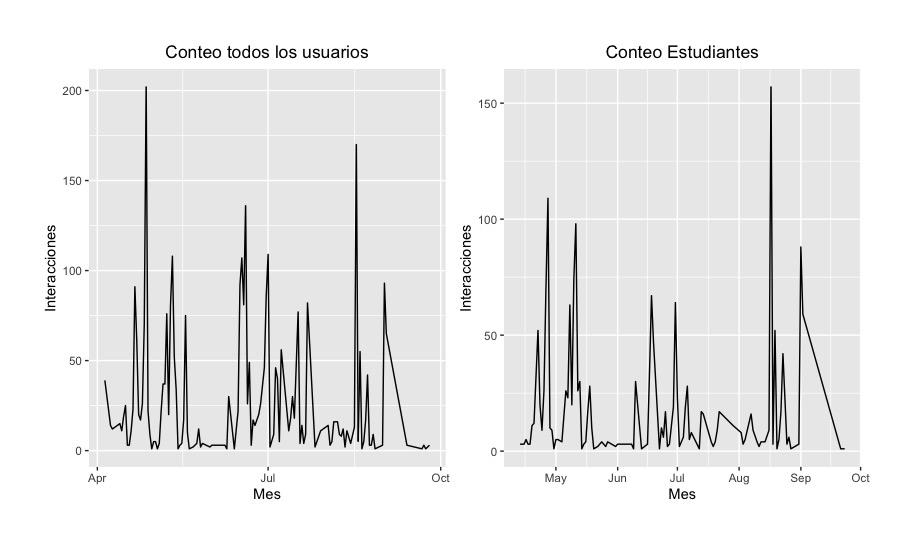

Figura1

Por otra parte, se realiza el mismo procedimiento para generar otro gráfico, esta vez de barras ajustando un degradado según el mínimo y máximo de registros. También se integran en un mismo plot para su comparación.

```
it_b <- ggplot(interacciones_cnt,aes(fecha, cnt, fill = cnt)) + geom_col() +
        scale_fill_gradient(low = "yellow", high = "red", na.value = NA) +
        ylab("Usuarios totales") + xlab("")
ut_b <- ggplot(usuarios_cnt,aes(fecha, cnt, fill = cnt)) + geom_col() +
        scale_fill_gradient(low = "yellow", high = "red", na.value = NA) +
        ylab("Participantes") + xlab("")
figura3 <- ggarrange(it_b, ut_b, ncol = 2, nrow = 1) +
          labs(title = "Interacciones a través del tiempo") +
          theme(plot.title = element_text(hjust = 0.5)) +
          theme(plot.margin = unit(c(1, 1, 1, 1), "cm"))
```

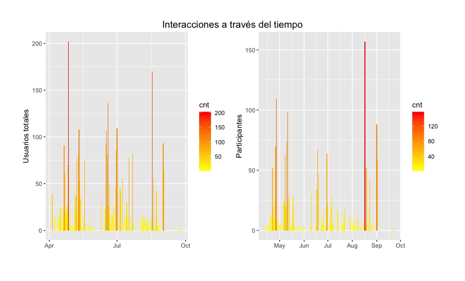

Figura1

En ambos gráficos se puede observar bajas en la cantidad de registros en los periodos comprendidos entre mayo y junio y otra baja en los meses de agosto. Por otra parte, ambos gráficos muestran un máximo de interacciones en diferentes periodos del año para las varialbes fecha y cnt(conteo). Con la función `summary()` se reportaron siguientes datos:

```
#Todos los usuarios

fecha                 cnt
 Min.   :2020-04-05   Min.   :  1.00
 1st Qu.:2020-05-09   1st Qu.:  4.00
 Median :2020-06-21   Median : 14.00
 Mean   :2020-06-21   Mean   : 27.66
 3rd Qu.:2020-08-03   3rd Qu.: 37.00
 Max.   :2020-09-25   Max.   :202.00
```

```
#Estudiantes

fecha                 cnt
 Min.   :2020-04-13   Min.   :  1.00
 1st Qu.:2020-05-11   1st Qu.:  3.00
 Median :2020-06-22   Median :  6.00
 Mean   :2020-06-20   Mean   : 18.39
 3rd Qu.:2020-08-02   3rd Qu.: 20.00
 Max.   :2020-09-23   Max.   :157.00
```

En los gráficos anteriores aún es complejo comparar ambas frecuencias de acceso a causa de las diferentes escalas. Por lo tanto, se genera un tercer plot en el que se sobreponen ambas gráficas.

```
figura2 <- ggplot(int_join, aes(fecha)) +
  geom_area(aes(y = Total), color = "blue", alpha=0.5, fill = "blue", linetype = "blank") +
  geom_area(aes(y = Participantes), color = "red", alpha=0.8, fill = "red", linetype = "blank") +
  labs(title = "Comparación de usuarios totales y participantes")+
  theme(plot.title = element_text(hjust = 0.5)) +
  ylab("Interacciones") + xlab("")+
  theme(plot.margin = unit(c(1, 1, 1, 1), "cm"))
figura2
```

En color azul se encuentra graficado los registros totales mientras que en color rojo se sobreponen los datos de los estudiantes. Uno de los elementos que sobresalen en este gráfico es la cantidad de usuarios que estaban presentes en plataforma durante el último mes de clases, lo que se mantuvo al excluir al administrador, profesor e investigador. También se observa en el resto del gráfico que durante los meses anteriores a agosto, existen más cantidad registros a causa de la administración, el profesor e investigador. Por otra parte, durante el primer mes hay registros sólo de la administración, profesor e investigador.

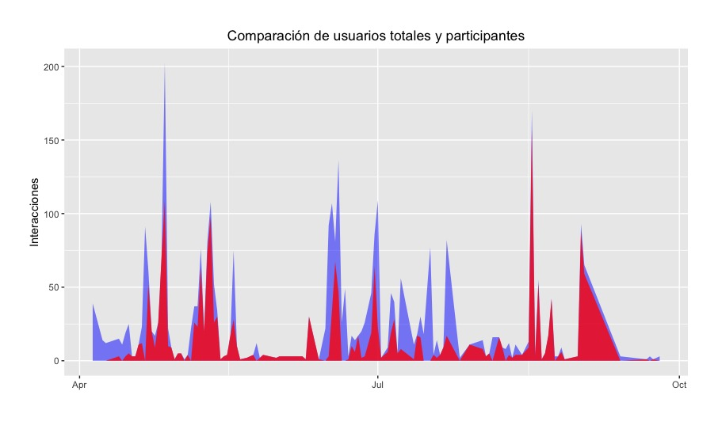

Para obtener una imagen más detallada de este periodo se extraen los datos entre el 02 de agosto y 02 de septiembre y se almacena en el objeto `ago.sep`. Se reemplazan las fechas faltantes entre estas fechas y se reemplazan por cero y posteriormente se grafica.

```
ago.sep <- filter(usuarios_cnt, usuarios_cnt$fecha >= "2020/08/01" & usuarios_cnt$fecha <= "2020/09/02")
ago.sep <- ago.sep %>% complete(fecha = seq.Date(min(fecha), max(fecha), by="day"))
ago.sep[is.na(ago.sep)] <- 0
ultimomes <- ggplot(ago.sep, aes(fecha, cnt)) + geom_line() + scale_x_date('Mes') +
  ylab("Interacciones") + xlab("") + labs(title="Último mes de clases") +
  theme(plot.title = element_text(hjust = 0.5))
```

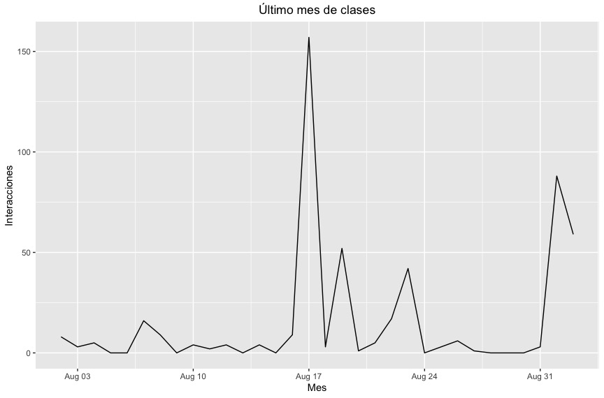

Figura1

```
> sum(ago.sep$cnt)
[1] 501
```

### Tabla de frecuencia

Para el análisis de los clúster se generó una tabla de frecuencia a partir de la variable `Contexto.del.evento` y `Nombre.completo.del.usuario`, la cual fue transformada a una matriz de contingencia. Además se escalaron los datos para hacer comparables las variables, procedimiento que consiste en que los datos tengan una media de "0" y una desviación estandar de 1.

```
UCE_escalado = as.data.frame.matrix(scale(UCE)) #Escalar
UCE_escalado
```

## Tarea de minería de datos

Se decide utilizar una tarea de agrupamiento que corresponde a las tareas de tipo descriptiva. La literatura también la describe como un método de análisis multivariante para la representación de relaciones. El agrupamiento tiene como objetivo encontrar grupos o conjuntos de elementos que entre sí sean similares (Hernández et al., 2010). Esto quiere decir que se busca que los elementos que pertenen a un grupo tengan un grado alto de similitud entre sí. En algunos casos se pueden determinar el número de grupos que se desea encontrar y en otros casos esto se puede determinar mediante un algoritmo de agrupamiento según las características de los datos (Hernández et al., 2010).

## Algoritmo de minería de datos

Para determinar la cantidad óptima de clúster existen varios métodos, entre ellos el método del codo, el método de silueta y Gap. En primera instancia, la idea de los métodos de particionamiento como el kmeans, es definir una cantidad de cluster en que la suma total de la variación intra clúster sea minimizada.

El método del codo consiste en examinar la fracción de la varianza en función del número de cluster (Wierzchoń & Kłopotek, 2018). Con este método, el total de la suma de los cuadrados intra cluster mide lo compacto del cluster, el cual debe ser lo más bajo posible. Los pasos que se realizan con este método son:

- Calcular un algoritmo de clustering para diferentes valores K, por ejemplo de 1 a 11 clúster.
- Para cada uno de los clúster calcular la suma total de los cuadrados internos.
- Graficar la curva de la suma total de los cuadrados internos.
- Observar y localizar el punto en que la línea se curva en el gráfico, indicador del número adecuado de clústers.

- Calcular un algoritmo de clustering para diferentes valores K, por ejemplo de 1 a 11 clúster.
- Para cada uno de los clúster calcular el promedio de la silueta.
- Graficar la curva del promedio de la silueta para cáda K cluster.
- El promedio máximo de la silueta corresponde al número apropiado de cluster.

GAP statistics compara el total de la variación intracluster para diferentes valores de k con los valores esperados bajo una distribución de referencia nula en los datos. Se supone que el valor de k, para el cual el rango es máximo, es la estimación probable del número de conglomerados (Wierzchoń & Kłopotek, 2018). El algoritmo trabaja de la siguiente forma:

- Calcula el algoritmo de cluster, para valores K=1, ..., K max, y calcula la variación total intra clúster.
- Genera un dataset de referencia con una distribución aleatoria uniforme, agrupa cada una de las referencias variando el número de cluster de K=1, ..., K max y calcula la correspondencia total de la variación intra cluster.
- Calcula la brecha estadística estimada de la correspondencia total de la variación intra cluster variación total intra cluster esperada. Calcula además la desviación estandar de las estadísticas.
- Elige el número de cluster como el valor más bajo de K, de tal modo que la brecha estadística se encuentre dentro de una desviación estandar de la brecha K+1. (Kassambara, 2017).

El algoritmo utilizado fue el K medias, que es un método de agrupamiento por vecindad, en que los datos con características similares se ubican en el espacio mediante sus centros o prototipos (Hernández et al., 2010). K medias opera directamente en una matriz de datos en busca de similitudes, y necesita un conjunto de posiciones tentativas alrededor de las cuales organizar grupos para el ajuste posterior.

[figure not shown]

Algoritmo K-means

El algoritmo realiza los siguientes pasos:

- Fijar el número de cluster igual o mayor a 2
- Calcula los centroides de cada cluster
- Asigna sus puntos mas cercanos al centroide
- Recalcula la posición del centroide y repite

## Minería de datos

Se cargó la librería `factoextra` y se ejecutó la función `fviz_nbclust` correspondiente para cada uno de los métodos.

### Cantidad óptima de Cluster para los usuarios

Aunque el método del codo no sugiere claramente un punto de quiebre en la curva, se podría asumir que desde el cuarto clúster hay un cambio de dirección más claro.

```
set.seed(123)
fviz_nbclust(UCE_escalado, kmeans, method = "wss")
```

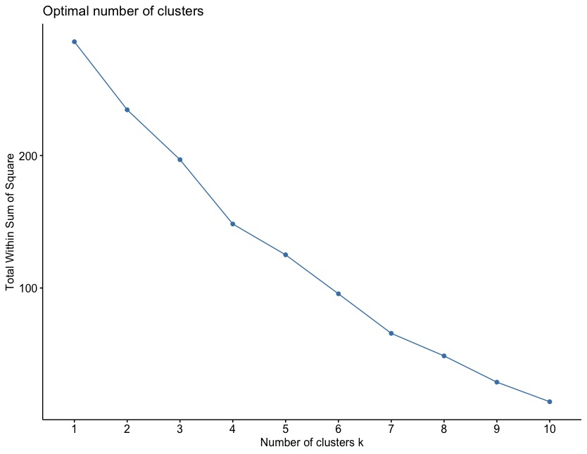

Elbow Method

Con respecto al método de silueta nos sugiere claramente que un número de 8 cluster es el ideal.

```
set.seed(123)
fviz_nbclust(UCE_escalado, kmeans, method = "sillhoutte")
```

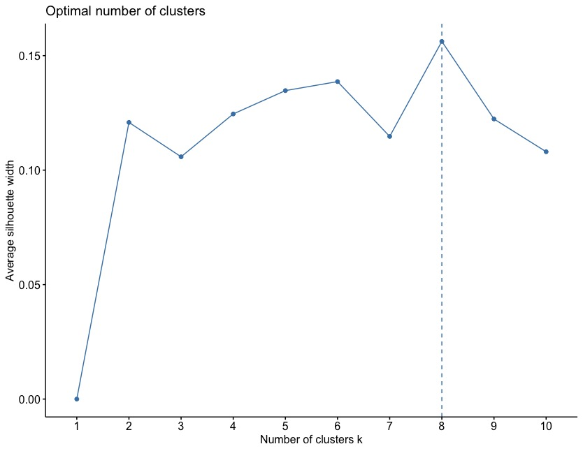

Silhouette Method

En el caso del método estadístico Gap, éste indica que estadísticamente el conjunto de datos se puede agrupar de forma óptima en un solo clúster.

```
set.seed(123)
fviz_nbclust(UCE_escalado, kmeans, method = "gap_stat")
```

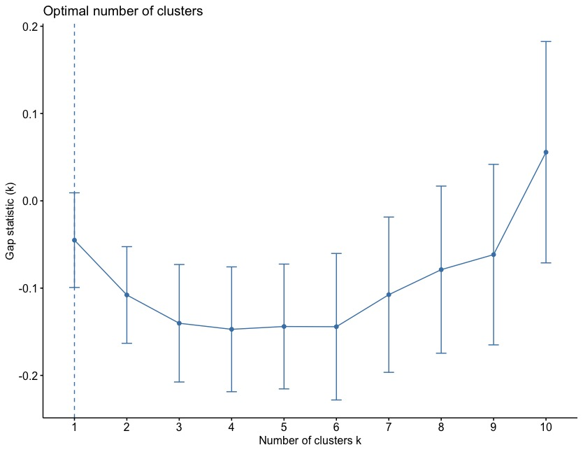

Gap Method

### Extracción de cluster de usuarios

Debido a que los métodos para determinar la cantidad de clúster óptimos difieren entre sí, se decide graficar la distribución de k=1 hasta k=4.

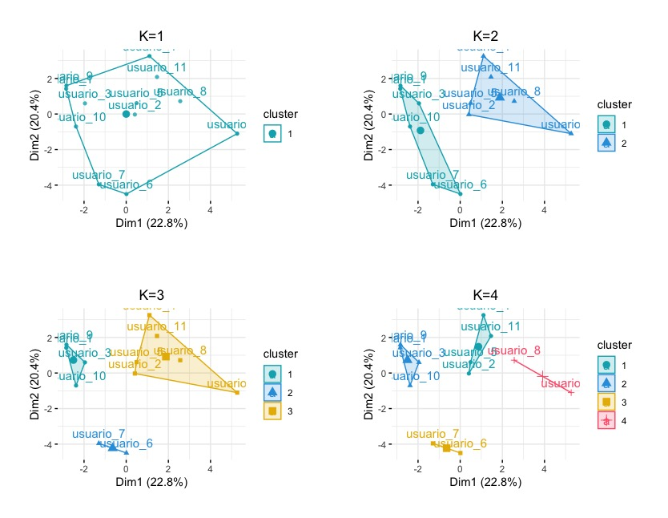

- La extracción de K=2 arrojó dos cluster de tamaño 6 y 6 con 20.1% de la suma de los cuadrados internos.
- La extracción con K=3 arrojó clúster de tamaño 4, 2 y 6 con un 35,7% de la suma de cuadrados internos.
- La extracción con K=4 encontró clúster de tamaño 4, 4, 2 y2 con un 48,1% de la suma de los cuadrados internos.

Con la misma tabla de frecuencias se realizó una segunda extracción de cluster para las actividades y recursos de la plataforma. Para esto, se realizó el mismo procedimiento anterior. En este caso se hizo una rotación de la tabla.

### Cantidad óptima de Cluster para los recursos de plataforma

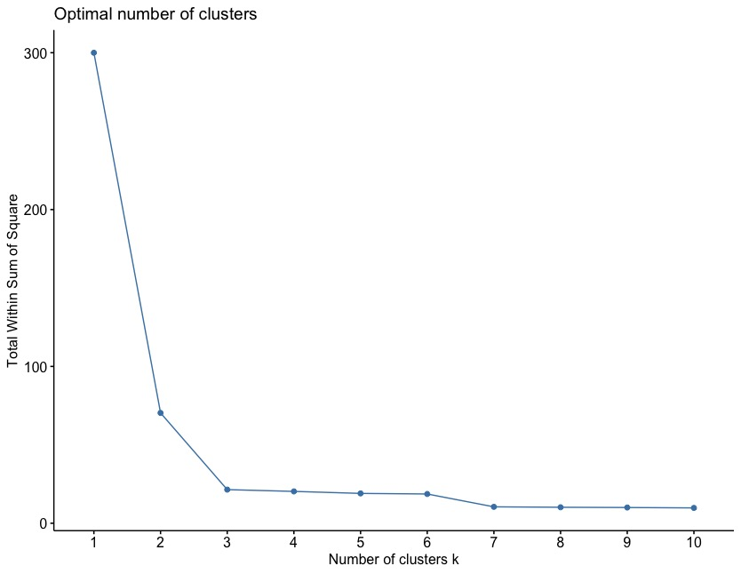

El método del ancho medio de la silueta también sugiere un corte de dos clúster.

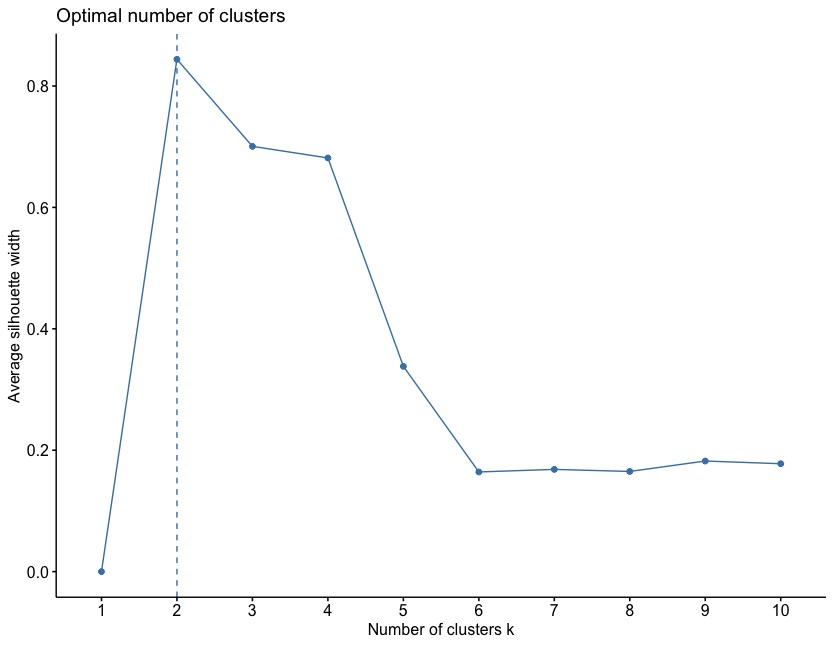

El tercer método sugiere que el número óptimo de cluster es de 1.

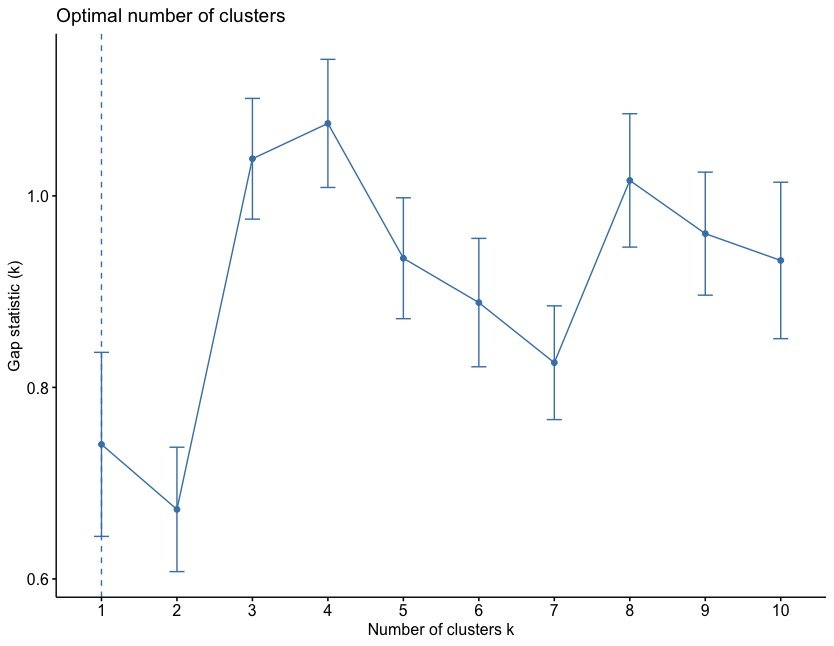

### Extraccion de clúster para recursos de la plataforma

En este caso específico dos de los tres métodos sugirieron un número óptimo de 2 cluster, por lo que se realizó la extracción y graficación.

```
cl_UCE_2 <- kmeans(UCE_escalado,2,nstart = 50, iter.max = 15)
p_UCE_cl2 <- fviz_cluster(cl_UCE_2, data = UCE_escalado,
                      palette = c("#00AFBB","#2E9FDF", "#E7B800"),
                      ggtheme = theme_minimal(),
                      main = "K=2"
) + theme(plot.margin = unit(c(1, 1, 1, 1), "cm")) + theme(plot.title = element_text(hjust = 0.5))
```

Se generaron dos clúster de tamaño 25 y 1 con un 76% de la suma interna de los cuadrados, en que el segundo grupo solo contiene la variable CURSO.

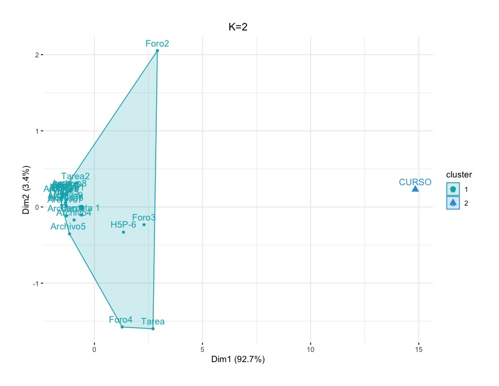

Aunque anteriormente los métodos para encontrar la cantidad máxima de clúster sugerían realizar la extracción con solo dos clúster, se realiza otra extracción con K=3. Debido a que la tabla de frecuencias de los recursos muestró que hay un recurso con una gran cantidad de registros (CURSO) y que las variables restantens tienen una frecuencias baja y media, por lo que podría existir una tercera agrupación que explique mejor los datos.

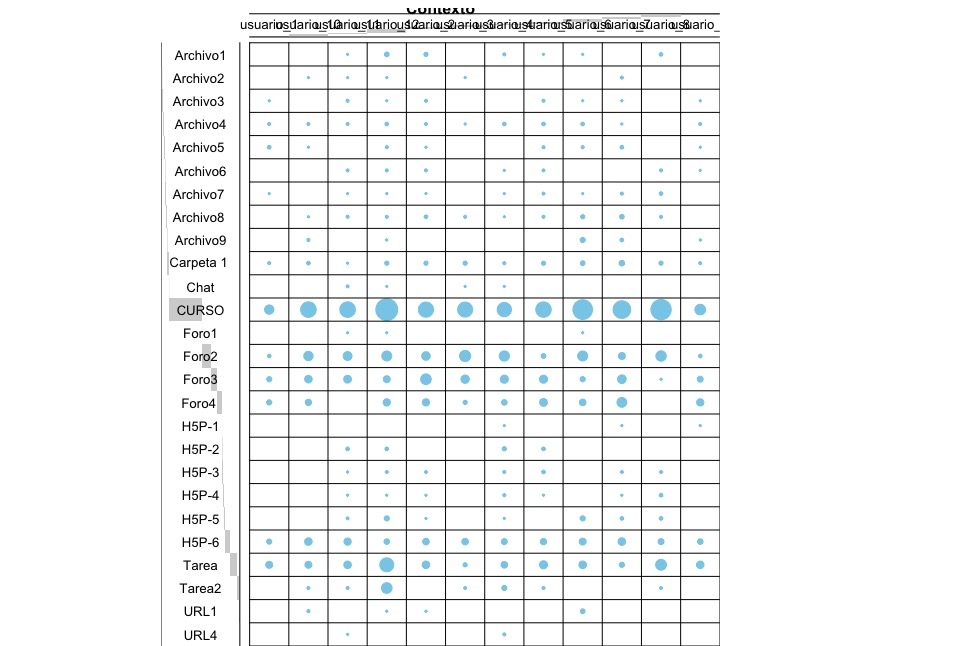

De esta modo, se generó tres grupos de 5, 20 y 1 observación con un 92,9% de la suma interna de los cuadrados.

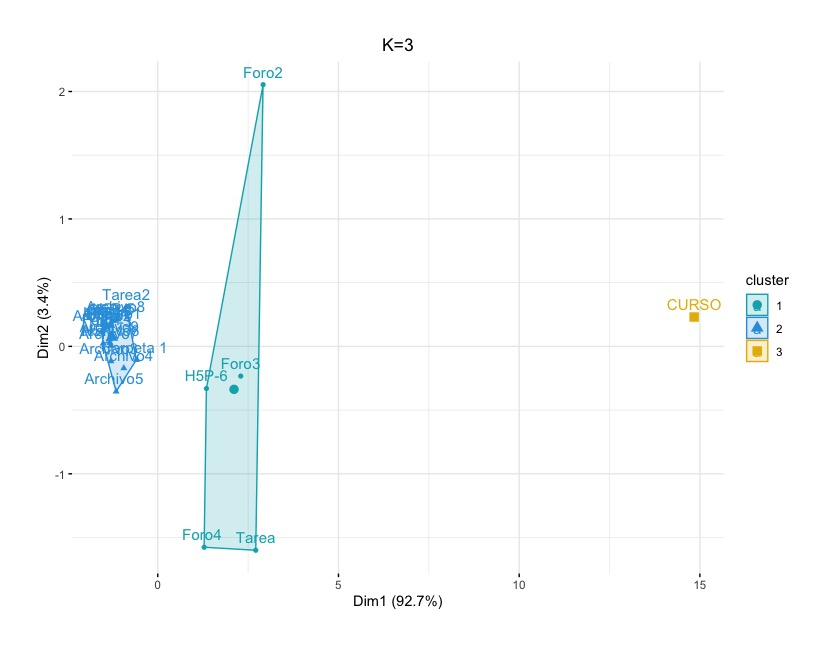

## Interpretación de patrones

En el análisis de cluster de estudiantes, se generaron 4 extracciones con K=1, K=2, K=3 y K=4, sin embargo el análisis para identiicar el número óptimo de clúster no fue concluyente. La extracción final con K=3 fue el que agrupó de mejor manera las variables de forma gráfica.

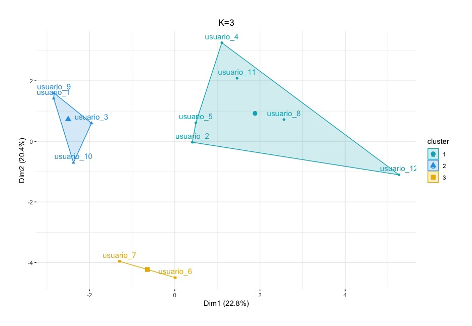

El modelo final con K=3 indica ser correcto, pero según la prueba Gap el conjunto de datos podría ser agrupado en un sólo cluster. Esto tiene sentido cuando observamos la extensión del conjunto de datos es pequeño y se observa en la tabla de frecuencias que el grupo es homogéneo. La excepción es el estudiante 12 que es el que más interactuó con la plataforma, pero que no se observa en las gráficas hasta el modelo con K=4. Una vez más, esto puede indicar que el valor K=1 para la agrupación por estudiantes es el modelo definitivo y que describe mejor el conjunto.

## Consolidación del conocimiento

El primer modelo de agrupación de estudiantes no generó resultados satisfactorios, principalmente porque el comportamiento del grupo fue homogéneo. Tal y como se visualizó en las frecuencias de acceso, todos los estudiantes ingresaron a la plataforma y mostrarin una mayor particioación al inicio y al final del periodo de clases. Aún así, se mantuvo una baja frecuencia de acceso, pero estable durante los demás meses en que se desarrolló el curso. Por esta razón, se puede concluir que K=1 representa de mejor manera el comportamiento general del grupo.

## Referencias

- Datanovia. (2020)K-Means Clustering in R: Algorithm and Practical Examples Datanovia.com https://www.datanovia.com/en/lessons/k-means-clustering-in-r-algorith-and-practical-examples/
- Hernández Orallo, J., Ramírez Quintana, M. J., & Ferri Ramírez, C. (2010). Introducción a la minería de datos. Pearson.
- Hussain, M., Hussain, S., Zhang, W., Zhu, W., Theodorou, P., & Abidi, S. M. R. (2018). Mining Moodle Data to Detect the Inactive and Low-performance Students during the Moodle Course. Proceedings of the 2nd International Conference on Big Data Research - ICBDR 2018, 133-140. https://doi.org/10.1145/3291801.3291828
- Moodle en números durante Covid-19. (2020, mayo 19). Moodle. https://moodle.com/es/news/moodle-en-numeros-durante-covid-19/
- Pradana, C., Kusumawardani, S. S., & Permanasari, A. E. (2020). Comparison Clustering Performance Based on Moodle Log Mining. IOP Conference Series: Materials Science and Engineering, 722, 012012. https://doi.org/10.1088/1757-899X/722/1/012012
- Romero, C., Ventura, S., & García, E. (2008). Data mining in course management systems: Moodle case study and tutorial. Computers & Education, 51(1), 368-384. https://doi.org/10.1016/j.compedu.2007.05.016
- W.L. Myers and G.P. Patil, Multivariate Methods of Representing Relations 13 in R for Prioritization Purposes, Environmental and Ecological Statistics 6, DOI 10.1007/978-1-4614-3122-0_2, © Springer Science+Business Media, LLC 2012
- Wierzchoń, S., & Kłopotek, M. (2018). Modern Algorithms of Cluster Analysis (Vol. 34). Springer International Publishing. https://doi.org/10.1007/978-3-319-69308-8